# Flights Dataset: Reporting Carrier On-Time Performance during Covid-19 Outbreak Exploration

## Preliminary Wrangling

```python
# import all packages and set plots to be embedded inline
import numpy as np
import pandas as pd
import matplotlib.pyplot as plt
import seaborn as sb

%matplotlib inline
```

> Loading datasets

##### December 2019

```python
dec_data=pd.read_csv('2019dec.csv', sep=';')
dec_data.head(5)
```

|  | YEAR | QUARTER | MONTH | DAY_OF_MONTH | DAY_OF_WEEK | FL_DATE | TAIL_NUM | OP_CARRIER_FL_NUM | ORIGIN_AIRPORT_ID | ORIGIN | ... | CRS_ELAPSED_TIME | ACTUAL_ELAPSED_TIME | AIR_TIME | FLIGHTS | DISTANCE | CARRIER_DELAY | WEATHER_DELAY | NAS_DELAY | SECURITY_DELAY | LATE_AIRCRAFT_DELAY |
| --- | --- | --- | --- | --- | --- | --- | --- | --- | --- | --- | --- | --- | --- | --- | --- | --- | --- | --- | --- | --- | --- |
| 0 | 2019 | 4 | 12 | 8 | 7 | 8.12.2019 | N8651A | 3689 | 15016 | STL | ... | 245.0 | 266.0 | 253.0 | 1.0 | 1557.0 | 0.0 | 0.0 | 18.0 | 0.0 | 0.0 |
| 1 | 2019 | 4 | 12 | 8 | 7 | 8.12.2019 | N939WN | 2600 | 15016 | STL | ... | 145.0 | 125.0 | 110.0 | 1.0 | 786.0 | NaN | NaN | NaN | NaN | NaN |
| 2 | 2019 | 4 | 12 | 8 | 7 | 8.12.2019 | N7741C | 2770 | 15016 | STL | ... | 140.0 | 131.0 | 120.0 | 1.0 | 786.0 | NaN | NaN | NaN | NaN | NaN |
| 3 | 2019 | 4 | 12 | 8 | 7 | 8.12.2019 | N550WN | 6654 | 15016 | STL | ... | 275.0 | 256.0 | 239.0 | 1.0 | 1709.0 | NaN | NaN | NaN | NaN | NaN |
| 4 | 2019 | 4 | 12 | 8 | 7 | 8.12.2019 | N8319F | 3402 | 15016 | STL | ... | 270.0 | 256.0 | 242.0 | 1.0 | 1735.0 | NaN | NaN | NaN | NaN | NaN |

5 rows × 35 columns

```python
dec_data.shape
```

```
(625763, 35)
```

##### January 2020

```python
jan_data=pd.read_csv('2020jan.csv', sep=';')
jan_data.head(5)
```

|  | YEAR | QUARTER | MONTH | DAY_OF_MONTH | DAY_OF_WEEK | FL_DATE | TAIL_NUM | OP_CARRIER_FL_NUM | ORIGIN_AIRPORT_ID | ORIGIN | ... | CRS_ELAPSED_TIME | ACTUAL_ELAPSED_TIME | AIR_TIME | FLIGHTS | DISTANCE | CARRIER_DELAY | WEATHER_DELAY | NAS_DELAY | SECURITY_DELAY | LATE_AIRCRAFT_DELAY |
| --- | --- | --- | --- | --- | --- | --- | --- | --- | --- | --- | --- | --- | --- | --- | --- | --- | --- | --- | --- | --- | --- |
| 0 | 2020 | 1 | 1 | 1 | 3 | 1.1.2020 | N951WN | 5888 | 13891 | ONT | ... | 95.0 | 122.0 | 74.0 | 1.0 | 363.0 | 8.0 | 0.0 | 27.0 | 0.0 | 33.0 |
| 1 | 2020 | 1 | 1 | 1 | 3 | 1.1.2020 | N467WN | 6276 | 13891 | ONT | ... | 90.0 | 92.0 | 71.0 | 1.0 | 363.0 | NaN | NaN | NaN | NaN | NaN |
| 2 | 2020 | 1 | 1 | 1 | 3 | 1.1.2020 | N7885A | 4598 | 13891 | ONT | ... | 70.0 | 68.0 | 57.0 | 1.0 | 333.0 | NaN | NaN | NaN | NaN | NaN |
| 3 | 2020 | 1 | 1 | 1 | 3 | 1.1.2020 | N551WN | 4761 | 13891 | ONT | ... | 75.0 | 75.0 | 63.0 | 1.0 | 333.0 | NaN | NaN | NaN | NaN | NaN |
| 4 | 2020 | 1 | 1 | 1 | 3 | 1.1.2020 | N968WN | 5162 | 13891 | ONT | ... | 80.0 | 67.0 | 57.0 | 1.0 | 333.0 | NaN | NaN | NaN | NaN | NaN |

5 rows × 35 columns

```python
jan_data.shape
```

```
(607346, 35)
```

##### February 2020

```python
feb_data=pd.read_csv('2020feb.csv', sep=';')
feb_data.head(5)
```

|  | YEAR | QUARTER | MONTH | DAY_OF_MONTH | DAY_OF_WEEK | FL_DATE | TAIL_NUM | OP_CARRIER_FL_NUM | ORIGIN_AIRPORT_ID | ORIGIN | ... | CRS_ELAPSED_TIME | ACTUAL_ELAPSED_TIME | AIR_TIME | FLIGHTS | DISTANCE | CARRIER_DELAY | WEATHER_DELAY | NAS_DELAY | SECURITY_DELAY | LATE_AIRCRAFT_DELAY |
| --- | --- | --- | --- | --- | --- | --- | --- | --- | --- | --- | --- | --- | --- | --- | --- | --- | --- | --- | --- | --- | --- |
| 0 | 2020 | 1 | 2 | 24 | 1 | 24.2.2020 | N697AB | 3820 | 11193 | CVG | ... | 159.0 | 147.0 | 132.0 | 1.0 | 948.0 | NaN | NaN | NaN | NaN | NaN |
| 1 | 2020 | 1 | 2 | 25 | 2 | 25.2.2020 | N622AE | 3820 | 11193 | CVG | ... | 159.0 | 156.0 | 137.0 | 1.0 | 948.0 | NaN | NaN | NaN | NaN | NaN |
| 2 | 2020 | 1 | 2 | 26 | 3 | 26.2.2020 | N677AE | 3820 | 11193 | CVG | ... | 159.0 | 185.0 | 146.0 | 1.0 | 948.0 | 0.0 | 0.0 | 26.0 | 0.0 | 25.0 |
| 3 | 2020 | 1 | 2 | 27 | 4 | 27.2.2020 | N905JH | 3820 | 11193 | CVG | ... | 159.0 | 150.0 | 128.0 | 1.0 | 948.0 | 0.0 | 0.0 | 0.0 | 0.0 | 55.0 |
| 4 | 2020 | 1 | 2 | 28 | 5 | 28.2.2020 | N664MS | 3820 | 11193 | CVG | ... | 159.0 | 173.0 | 131.0 | 1.0 | 948.0 | 4.0 | 0.0 | 14.0 | 0.0 | 0.0 |

5 rows × 35 columns

```python
feb_data.shape
```

```
(574268, 35)
```

##### March 2020

```python
march_data=pd.read_csv('2020march.csv', sep=';')
march_data.head(5)
```

|  | YEAR | QUARTER | MONTH | DAY_OF_MONTH | DAY_OF_WEEK | FL_DATE | TAIL_NUM | OP_CARRIER_FL_NUM | ORIGIN_AIRPORT_ID | ORIGIN | ... | CRS_ELAPSED_TIME | ACTUAL_ELAPSED_TIME | AIR_TIME | FLIGHTS | DISTANCE | CARRIER_DELAY | WEATHER_DELAY | NAS_DELAY | SECURITY_DELAY | LATE_AIRCRAFT_DELAY |
| --- | --- | --- | --- | --- | --- | --- | --- | --- | --- | --- | --- | --- | --- | --- | --- | --- | --- | --- | --- | --- | --- |
| 0 | 2020 | 1 | 3 | 13 | 5 | 13.3.2020 | N503AE | 5065 | 10599 | BHM | ... | 133.0 | 131.0 | 108.0 | 1.0 | 772.0 | NaN | NaN | NaN | NaN | NaN |
| 1 | 2020 | 1 | 3 | 14 | 6 | 14.3.2020 | N500AE | 5065 | 10599 | BHM | ... | 133.0 | 128.0 | 107.0 | 1.0 | 772.0 | NaN | NaN | NaN | NaN | NaN |
| 2 | 2020 | 1 | 3 | 15 | 7 | 15.3.2020 | N703PS | 5065 | 10599 | BHM | ... | 133.0 | 108.0 | 95.0 | 1.0 | 772.0 | NaN | NaN | NaN | NaN | NaN |
| 3 | 2020 | 1 | 3 | 16 | 1 | 16.3.2020 | N544EA | 5065 | 10599 | BHM | ... | 133.0 | 118.0 | 102.0 | 1.0 | 772.0 | NaN | NaN | NaN | NaN | NaN |
| 4 | 2020 | 1 | 3 | 17 | 2 | 17.3.2020 | N542EA | 5065 | 10599 | BHM | ... | 133.0 | 116.0 | 96.0 | 1.0 | 772.0 | NaN | NaN | NaN | NaN | NaN |

5 rows × 35 columns

```python
march_data.shape
```

```
(648233, 35)
```

Combine these datasets (December 2019-March 2020)

```python
all_data = pd.concat([dec_data,jan_data,feb_data, march_data])
all_data.head(5)
```

|  | YEAR | QUARTER | MONTH | DAY_OF_MONTH | DAY_OF_WEEK | FL_DATE | TAIL_NUM | OP_CARRIER_FL_NUM | ORIGIN_AIRPORT_ID | ORIGIN | ... | CRS_ELAPSED_TIME | ACTUAL_ELAPSED_TIME | AIR_TIME | FLIGHTS | DISTANCE | CARRIER_DELAY | WEATHER_DELAY | NAS_DELAY | SECURITY_DELAY | LATE_AIRCRAFT_DELAY |
| --- | --- | --- | --- | --- | --- | --- | --- | --- | --- | --- | --- | --- | --- | --- | --- | --- | --- | --- | --- | --- | --- |
| 0 | 2019 | 4 | 12 | 8 | 7 | 8.12.2019 | N8651A | 3689 | 15016 | STL | ... | 245.0 | 266.0 | 253.0 | 1.0 | 1557.0 | 0.0 | 0.0 | 18.0 | 0.0 | 0.0 |
| 1 | 2019 | 4 | 12 | 8 | 7 | 8.12.2019 | N939WN | 2600 | 15016 | STL | ... | 145.0 | 125.0 | 110.0 | 1.0 | 786.0 | NaN | NaN | NaN | NaN | NaN |
| 2 | 2019 | 4 | 12 | 8 | 7 | 8.12.2019 | N7741C | 2770 | 15016 | STL | ... | 140.0 | 131.0 | 120.0 | 1.0 | 786.0 | NaN | NaN | NaN | NaN | NaN |
| 3 | 2019 | 4 | 12 | 8 | 7 | 8.12.2019 | N550WN | 6654 | 15016 | STL | ... | 275.0 | 256.0 | 239.0 | 1.0 | 1709.0 | NaN | NaN | NaN | NaN | NaN |
| 4 | 2019 | 4 | 12 | 8 | 7 | 8.12.2019 | N8319F | 3402 | 15016 | STL | ... | 270.0 | 256.0 | 242.0 | 1.0 | 1735.0 | NaN | NaN | NaN | NaN | NaN |

5 rows × 35 columns

```python
#Check if merging rows is succesfull by comparing number of rows, should be True
all_data.shape[0] == (dec_data.shape[0] +jan_data.shape[0] +feb_data.shape[0]+ march_data.shape[0])
```

```
True
```

```python
all_data.shape
```

```
(2455610, 35)
```

```python
#Check for duplicates, should be zero
all_data.duplicated().sum()
```

```
0
```

```python
all_data.dtypes
```

```
YEAR                     int64
QUARTER                  int64
MONTH                    int64
DAY_OF_MONTH             int64
DAY_OF_WEEK              int64
FL_DATE                 object
TAIL_NUM                object
OP_CARRIER_FL_NUM        int64
ORIGIN_AIRPORT_ID        int64
ORIGIN                  object
ORIGIN_CITY_NAME        object
DEST_AIRPORT_ID          int64
DEST                    object
DEST_CITY_NAME          object
CRS_DEP_TIME             int64
DEP_TIME               float64
DEP_DELAY              float64
TAXI_OUT               float64
TAXI_IN                float64
CRS_ARR_TIME             int64
ARR_TIME               float64
ARR_DELAY              float64
CANCELLED              float64
CANCELLATION_CODE       object
DIVERTED               float64
CRS_ELAPSED_TIME       float64
ACTUAL_ELAPSED_TIME    float64
AIR_TIME               float64
FLIGHTS                float64
DISTANCE               float64
CARRIER_DELAY          float64
WEATHER_DELAY          float64
NAS_DELAY              float64
SECURITY_DELAY         float64
LATE_AIRCRAFT_DELAY    float64
dtype: object
```

Convert YEAR, QUARTER, MONTH, DAY_OF_MONTH, DAY_OF_WEEK, OP_CARRIER_FL_NUM, ORIGIN_AIRPORT_ID, DEST_AIRPORT_ID to string

```python
col_names= ['YEAR', 'QUARTER', 'MONTH', 'DAY_OF_MONTH', 'DAY_OF_WEEK', 'OP_CARRIER_FL_NUM', 'ORIGIN_AIRPORT_ID', 'DEST_AIRPORT_ID', 'CANCELLED', 'DIVERTED']

# loop to change each column to category type
for col in col_names:
    all_data[col] = all_data[col].astype('str',copy=False)

# loop to change each column to category type
for col in col_names:
    dec_data[col] = dec_data[col].astype('str',copy=False)

# loop to change each column to category type
for col in col_names:
    jan_data[col] = jan_data[col].astype('str',copy=False)

# loop to change each column to category type
for col in col_names:
    feb_data[col] = feb_data[col].astype('str',copy=False)

# loop to change each column to category type
for col in col_names:
    march_data[col] = march_data[col].astype('str',copy=False)
```

```python
all_data.describe()
```

|  | CRS_DEP_TIME | DEP_TIME | DEP_DELAY | TAXI_OUT | TAXI_IN | CRS_ARR_TIME | ARR_TIME | ARR_DELAY | CRS_ELAPSED_TIME | ACTUAL_ELAPSED_TIME | AIR_TIME | FLIGHTS | DISTANCE | CARRIER_DELAY | WEATHER_DELAY | NAS_DELAY | SECURITY_DELAY | LATE_AIRCRAFT_DELAY |
| --- | --- | --- | --- | --- | --- | --- | --- | --- | --- | --- | --- | --- | --- | --- | --- | --- | --- | --- |
| count | 2.455610e+06 | 2.328540e+06 | 2.328490e+06 | 2.327935e+06 | 2.326842e+06 | 2.455610e+06 | 2.326842e+06 | 2.323200e+06 | 2.455610e+06 | 2.323200e+06 | 2.323200e+06 | 2455610.0 | 2.455610e+06 | 347566.000000 | 347566.000000 | 347566.000000 | 347566.000000 | 347566.000000 |
| mean | 1.331669e+03 | 1.334652e+03 | 7.045393e+00 | 1.710540e+01 | 7.483509e+00 | 1.489067e+03 | 1.473471e+03 | -3.065586e-01 | 1.443047e+02 | 1.371886e+02 | 1.126090e+02 | 1.0 | 8.023492e+02 | 23.123154 | 3.481978 | 15.104760 | 0.085615 | 24.191889 |
| std | 4.938207e+02 | 5.034807e+02 | 4.468532e+01 | 9.574435e+00 | 5.741143e+00 | 5.238111e+02 | 5.344190e+02 | 4.684160e+01 | 7.242979e+01 | 7.228486e+01 | 7.058340e+01 | 0.0 | 5.864713e+02 | 72.357717 | 32.402518 | 34.366289 | 2.897956 | 53.486758 |
| min | 1.000000e+00 | 1.000000e+00 | -8.000000e+01 | 1.000000e+00 | 1.000000e+00 | 1.000000e+00 | 1.000000e+00 | -1.170000e+02 | -7.700000e+01 | 1.500000e+01 | 8.000000e+00 | 1.0 | 3.100000e+01 | 0.000000 | 0.000000 | 0.000000 | 0.000000 | 0.000000 |
| 25% | 9.150000e+02 | 9.170000e+02 | -6.000000e+00 | 1.100000e+01 | 4.000000e+00 | 1.103000e+03 | 1.053000e+03 | -1.800000e+01 | 9.100000e+01 | 8.500000e+01 | 6.100000e+01 | 1.0 | 3.700000e+02 | 0.000000 | 0.000000 | 0.000000 | 0.000000 | 0.000000 |
| 50% | 1.325000e+03 | 1.329000e+03 | -3.000000e+00 | 1.500000e+01 | 6.000000e+00 | 1.519000e+03 | 1.511000e+03 | -9.000000e+00 | 1.270000e+02 | 1.200000e+02 | 9.500000e+01 | 1.0 | 6.460000e+02 | 0.000000 | 0.000000 | 2.000000 | 0.000000 | 0.000000 |
| 75% | 1.739000e+03 | 1.744000e+03 | 3.000000e+00 | 2.000000e+01 | 9.000000e+00 | 1.924000e+03 | 1.920000e+03 | 3.000000e+00 | 1.750000e+02 | 1.680000e+02 | 1.430000e+02 | 1.0 | 1.044000e+03 | 20.000000 | 0.000000 | 19.000000 | 0.000000 | 28.000000 |
| max | 2.359000e+03 | 2.400000e+03 | 2.814000e+03 | 1.890000e+02 | 1.940000e+02 | 2.400000e+03 | 2.400000e+03 | 2.794000e+03 | 7.050000e+02 | 7.630000e+02 | 6.980000e+02 | 1.0 | 5.095000e+03 | 2695.000000 | 1847.000000 | 1462.000000 | 1185.000000 | 2228.000000 |

```python
#Change the letters into cancellation reasons
all_data['CANCELLATION_CODE']=all_data['CANCELLATION_CODE'].str[0].str.upper().map({ 'A' : 'carrier', 'B' : 'weather', 'C': 'NAS', 'D':'security'})
all_data['CANCELLATION_CODE'].value_counts()
```

```
security    97872
weather     14215
carrier     11947
NAS          4013
Name: CANCELLATION_CODE, dtype: int64
```

```python
#Change the letters into cancellation reasons for other subsets of data
dec_data['CANCELLATION_CODE']=dec_data['CANCELLATION_CODE'].str[0].str.upper().map({ 'A' : 'carrier', 'B' : 'weather', 'C': 'NAS', 'D':'security'})
jan_data['CANCELLATION_CODE']=jan_data['CANCELLATION_CODE'].str[0].str.upper().map({ 'A' : 'carrier', 'B' : 'weather', 'C': 'NAS', 'D':'security'})
feb_data['CANCELLATION_CODE']=feb_data['CANCELLATION_CODE'].str[0].str.upper().map({ 'A' : 'carrier', 'B' : 'weather', 'C': 'NAS', 'D':'security'})
march_data['CANCELLATION_CODE']=march_data['CANCELLATION_CODE'].str[0].str.upper().map({ 'A' : 'carrier', 'B' : 'weather', 'C': 'NAS', 'D':'security'})
```

### What is the structure of your dataset?

Dataset includes flight information in US during Covid-19 outbreak from December to March. There are 2455610 flight information with 35 variables including flight details and delays. The variables in dataset were explained below.

### What is/are the main feature(s) of interest in your dataset?

As the effects of Covid-19 outbreak on flights are investigated, MONTH, DEST_CITY_NAME, DEP_DELAY, ARR_DELAY, CANCELLATION_CODE features were used in analyses.

### What features in the dataset do you think will help support your investigation into your feature(s) of interest?

Number of DIVERTED and CANCELLED flight are also useful.

## Univariate Exploration

> In this section, I will investigate distributions of individual variables. First, I want to know the distribution of flight delays in departure and arrival time in different months

#### Distribution of departure delay time

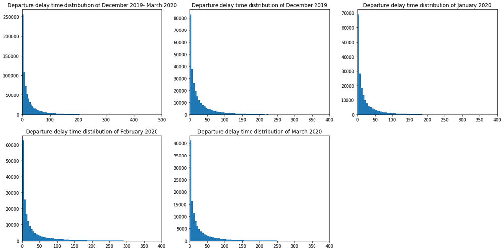

```python
plt.figure(figsize=[20,10])
binsize=5

plt.subplot(2,3,1)
bins1=np.arange(0, all_data['DEP_DELAY'].max()+binsize,binsize)
plt.hist(data=all_data, x='DEP_DELAY', bins=bins1)
plt.xlim((0,500))
plt.title('Departure delay time distribution of December 2019- March 2020')

plt.subplot(2,3,2)
bins2=np.arange(0, dec_data['DEP_DELAY'].max()+binsize,binsize)
plt.hist(data=dec_data, x='DEP_DELAY', bins=bins2)
plt.xlim((0,400))
plt.title('Departure delay time distribution of December 2019')

plt.subplot(2,3,3)
bins3=np.arange(0, jan_data['DEP_DELAY'].max()+binsize,binsize)
plt.hist(data=jan_data, x='DEP_DELAY', bins=bins3)
plt.xlim((0,400))
plt.title('Departure delay time distribution of January 2020')

plt.subplot(2,3,4)
bins4=np.arange(0, feb_data['DEP_DELAY'].max()+binsize,binsize)
plt.hist(data=feb_data, x='DEP_DELAY', bins=bins4)
plt.xlim((0,400))
plt.title('Departure delay time distribution of February 2020')

plt.subplot(2,3,5)
bins5=np.arange(0, march_data['DEP_DELAY'].max()+binsize,binsize)
plt.hist(data=march_data, x='DEP_DELAY', bins=bins5)
plt.xlim((0,400))
plt.title('Departure delay time distribution of March 2020');
```

The distributions of departure time delays during four months look same. Besides, it looks like up to five minutes delay is very common and considered to be normal.

#### Distribution of arrival delay time

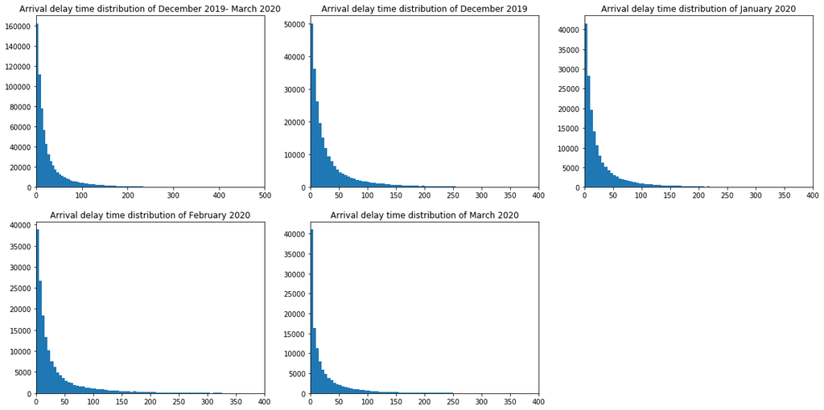

```python
plt.figure(figsize=[20,10])
binsize=5

plt.subplot(2,3,1)
bins1=np.arange(0, all_data['ARR_DELAY'].max()+binsize,binsize)
plt.hist(data=all_data, x='ARR_DELAY', bins=bins1)
plt.xlim((0,500))
plt.title('Arrival delay time distribution of December 2019- March 2020')

plt.subplot(2,3,2)
bins2=np.arange(0, dec_data['ARR_DELAY'].max()+binsize,binsize)
plt.hist(data=dec_data, x='ARR_DELAY', bins=bins2)
plt.xlim((0,400))
plt.title('Arrival delay time distribution of December 2019')

plt.subplot(2,3,3)
bins3=np.arange(0, jan_data['ARR_DELAY'].max()+binsize,binsize)
plt.hist(data=jan_data, x='ARR_DELAY', bins=bins3)
plt.xlim((0,400))
plt.title('Arrival delay time distribution of January 2020')

plt.subplot(2,3,4)
bins4=np.arange(0, feb_data['ARR_DELAY'].max()+binsize,binsize)
plt.hist(data=feb_data, x='ARR_DELAY', bins=bins4)
plt.xlim((0,400))
plt.title('Arrival delay time distribution of February 2020')

plt.subplot(2,3,5)
bins5=np.arange(0, march_data['DEP_DELAY'].max()+binsize,binsize)
plt.hist(data=march_data, x='DEP_DELAY', bins=bins5)
plt.xlim((0,400))
plt.title('Arrival delay time distribution of March 2020');
```

The delays in arrivals provided us the same information with the departure delays.

#### What about the cancelled flights?

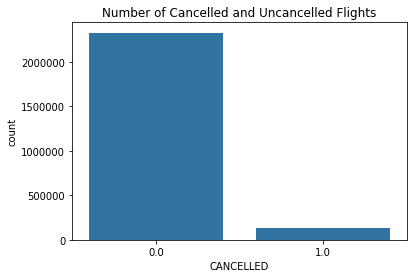

```python
# let's look to the ratio of cancelled flight.
base_color = sb.color_palette()[0]
sb.countplot(data = all_data, x = 'CANCELLED', color = base_color)
plt.title('Number of Cancelled and Uncancelled Flights');
```

#### What about the reasons of cancellations?

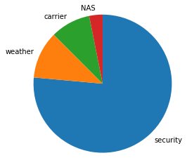

```python
sorted_counts=all_data['CANCELLATION_CODE'].value_counts()
plt.pie(sorted_counts, labels=sorted_counts.index, startangle=90, counterclock=False)
plt.axis('square');
```

Security based cancellations are very dominant during four months.

#### Are there many diverted flights?

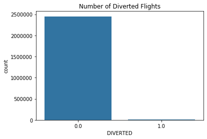

```python
base_color = sb.color_palette()[0]
sb.countplot(data = all_data, x = 'DIVERTED', color = base_color)
plt.title('Number of Diverted Flights');
```

It is a rare ocasion.

#### Let's investigate the top flight destinations in US

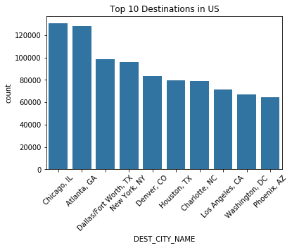

```python
base_color = sb.color_palette()[0]
chart=sb.countplot(data=all_data, x='DEST_CITY_NAME', order=all_data.DEST_CITY_NAME.value_counts().iloc[:10].index, color=base_color)
plt.title('Top 10 Destinations in US', size=12)
plt.figure(figsize=(15,50))
chart.set_xticklabels(chart.get_xticklabels(), rotation=45);
```

#### Are these top 10 destinations change by month of the year or remains same?

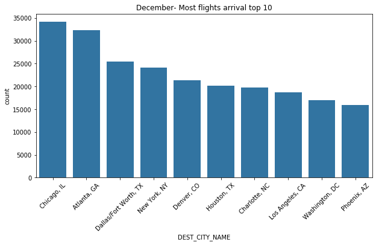

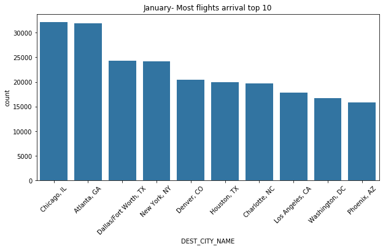

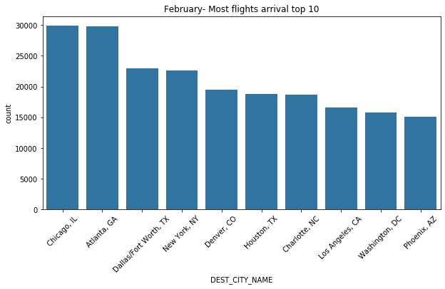

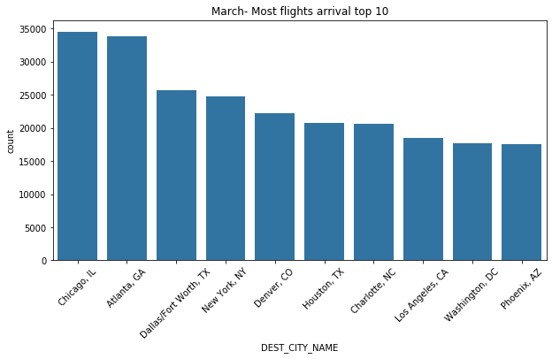

```python
base_color = sb.color_palette()[0]

plt.figure(figsize=[10,5])
sb.countplot(data=dec_data, x='DEST_CITY_NAME', order=dec_data.DEST_CITY_NAME.value_counts().iloc[:10].index, color=base_color).set_xticklabels(chart.get_xticklabels(), rotation=45)
plt.title('December- Most flights arrival top 10', size=12)


plt.figure(figsize=[10,5])
sb.countplot(data=jan_data, x='DEST_CITY_NAME', order=jan_data.DEST_CITY_NAME.value_counts().iloc[:10].index, color=base_color).set_xticklabels(chart.get_xticklabels(), rotation=45)
plt.title('January- Most flights arrival top 10', size=12)


plt.figure(figsize=[10,5])
chart2=sb.countplot(data=feb_data, x='DEST_CITY_NAME', order=feb_data.DEST_CITY_NAME.value_counts().iloc[:10].index, color=base_color).set_xticklabels(chart.get_xticklabels(), rotation=45)
plt.title('February- Most flights arrival top 10', size=12)


plt.figure(figsize=[10,5])
chart3=sb.countplot(data=march_data, x='DEST_CITY_NAME', order=march_data.DEST_CITY_NAME.value_counts().iloc[:10].index, color=base_color).set_xticklabels(chart.get_xticklabels(), rotation=45)
plt.title('March- Most flights arrival top 10', size=12);
```

Top 10 cities are found to be same for four months.

#### What is the flight time distribution in US?

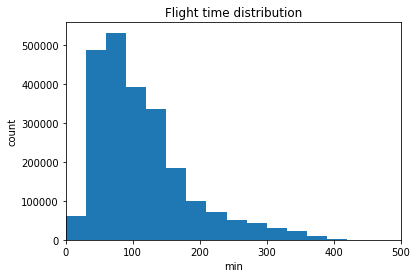

```python
binsize=30
bins=np.arange(0, all_data['AIR_TIME'].max()+binsize,binsize)
plt.hist(data=all_data, x='AIR_TIME', bins=bins)
plt.title('Flight time distribution')
plt.xlim((0,500))
plt.xlabel('min')
plt.ylabel('count');
```

The distribution is found to be right skewed. Most of the flights are less than three hours.

## Bivariate Exploration

#### Let's investigate the delay times in departure and arrival for different months

Firstly, the distributions in different months are shown below.

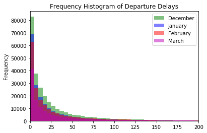

```python
#Distribution for departure delays
bins=np.arange(0, all_data['DEP_DELAY'].max()+binsize,5)
kwargs = dict(alpha=0.5)

plt.hist(dec_data['DEP_DELAY'], **kwargs, bins=bins, color='g', label='December')
plt.hist(jan_data['DEP_DELAY'], **kwargs,bins=bins, color='b', label='January')
plt.hist(feb_data['DEP_DELAY'], **kwargs, bins=bins,color='r', label='February')
plt.hist(march_data['DEP_DELAY'], **kwargs,bins=bins, color='m', label='March')
plt.gca().set(title='Frequency Histogram of Departure Delays', ylabel='Frequency')
plt.xlim(0,200)
plt.legend();
```

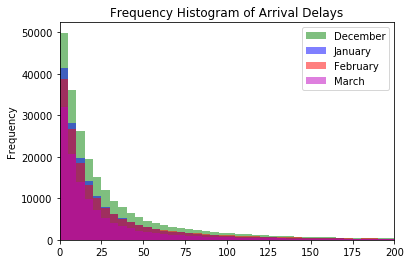

```python
#Distribution for arrival delays
bins=np.arange(0, all_data['ARR_DELAY'].max()+binsize,5)
kwargs = dict(alpha=0.5)

plt.hist(dec_data['ARR_DELAY'], **kwargs, bins=bins, color='g', label='December')
plt.hist(jan_data['ARR_DELAY'], **kwargs,bins=bins, color='b', label='January')
plt.hist(feb_data['ARR_DELAY'], **kwargs, bins=bins,color='r', label='February')
plt.hist(march_data['ARR_DELAY'], **kwargs,bins=bins, color='m', label='March')
plt.gca().set(title='Frequency Histogram of Arrival Delays', ylabel='Frequency')
plt.xlim(0,200)
plt.legend();
```

Delay times for both arrival and departure looks very similar in different months except number of flights.

In order to be sure, let's look up to their box plots to compare.

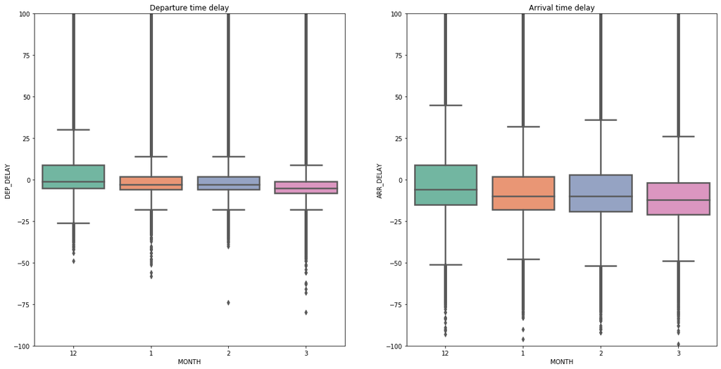

```python
plt.figure(figsize=[20,10])
plt.subplot(1,2,1)
sb.boxplot(data=all_data, x="MONTH", y="DEP_DELAY",linewidth=2.5, order=["12", "1", "2", "3"], palette="Set2")
plt.ylim((-100,100))
plt.title('Departure time delay')

plt.subplot(1,2,2)
sb.boxplot(data=all_data, x="MONTH", y="ARR_DELAY",linewidth=2.5, order=["12", "1", "2", "3"], palette="Set2")
plt.ylim((-100,100))
plt.title('Arrival time delay');
```

The medians look very close to each other, hence Covid-19 did not affect the flight delays.

#### How did number of flights change by time?

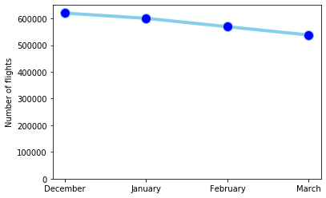

```python
flight_data = {'Month':  ['December', 'January','February', 'March'],
        'Flight_number': [dec_data[dec_data['CANCELLED']=='0.0'].shape[0], jan_data[jan_data['CANCELLED']=='0.0'].shape[0],feb_data[feb_data['CANCELLED']=='0.0'].shape[0], march_data[march_data['CANCELLED']=='0.0'].shape[0]]
 }

df_flight = pd.DataFrame (flight_data, columns = ['Month','Flight_number'])


plt.plot( 'Month', 'Flight_number', data=df_flight, marker='o', markerfacecolor='blue', markersize=12, color='skyblue', linewidth=4)
plt.ylabel('Number of flights')
plt.ylim((0,650000));
```

In figure above, a decrease in the number of flights in US can be seen.

#### Let's investigate the number of flight cancellations per months

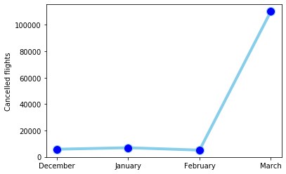

```python
data = {'Month':  ['December', 'January','February', 'March'],
        'Cancellation': [dec_data[dec_data['CANCELLED']=='1.0'].shape[0], jan_data[jan_data['CANCELLED']=='1.0'].shape[0],feb_data[feb_data['CANCELLED']=='1.0'].shape[0], march_data[march_data['CANCELLED']=='1.0'].shape[0]]
 }

df = pd.DataFrame (data, columns = ['Month','Cancellation'])


plt.plot( 'Month', 'Cancellation', data=df, marker='o', markerfacecolor='blue', markersize=12, color='skyblue', linewidth=4)
plt.ylabel('Cancelled flights');
```

Here, the number of cancelled domestic flights increased tremendously. This case is related to restrictions due to Covid-19 spread in US on March.

#### Why were the flights cancelled?

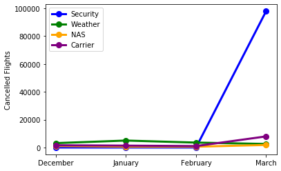

```python
data2 = {'Month':  ['December', 'January','February', 'March'],
        'Security': [dec_data[dec_data['CANCELLATION_CODE']=='security'].shape[0], jan_data[jan_data['CANCELLATION_CODE']=='security'].shape[0],feb_data[feb_data['CANCELLATION_CODE']=='security'].shape[0], march_data[march_data['CANCELLATION_CODE']=='security'].shape[0]],
         'Weather': [dec_data[dec_data['CANCELLATION_CODE']=='weather'].shape[0], jan_data[jan_data['CANCELLATION_CODE']=='weather'].shape[0],feb_data[feb_data['CANCELLATION_CODE']=='weather'].shape[0], march_data[march_data['CANCELLATION_CODE']=='weather'].shape[0]],
         'NAS': [dec_data[dec_data['CANCELLATION_CODE']=='NAS'].shape[0], jan_data[jan_data['CANCELLATION_CODE']=='NAS'].shape[0],feb_data[feb_data['CANCELLATION_CODE']=='NAS'].shape[0], march_data[march_data['CANCELLATION_CODE']=='NAS'].shape[0]],
         'Carrier': [dec_data[dec_data['CANCELLATION_CODE']=='carrier'].shape[0], jan_data[jan_data['CANCELLATION_CODE']=='carrier'].shape[0],feb_data[feb_data['CANCELLATION_CODE']=='carrier'].shape[0], march_data[march_data['CANCELLATION_CODE']=='carrier'].shape[0]]
 }

df2 = pd.DataFrame (data2, columns = ['Month','Security', 'Weather', 'NAS', 'Carrier'])

plt.plot( 'Month', 'Security', data=df2, marker='o', markerfacecolor='blue', markersize=8, color='blue', linewidth=3)
plt.plot( 'Month', 'Weather', data=df2, marker='o', markerfacecolor='green', markersize=8, color='green', linewidth=3)
plt.plot( 'Month', 'NAS', data=df2, marker='o', markerfacecolor='orange', markersize=8, color='orange', linewidth=3)
plt.plot( 'Month', 'Carrier', data=df2, marker='o', markerfacecolor='purple', markersize=8, color='purple', linewidth=3)
plt.ylabel('Cancelled Flights')
plt.legend();
```

Before March, the majority of the cancellations were due to weather conditions, however, security reasons became more dominant in March.

#### Is there any increase in number of diverted flights?

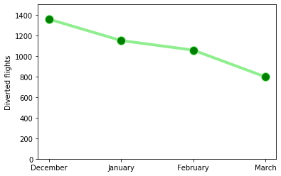

```python
data3 = {'Month':  ['December', 'January','February', 'March'],
        'Diverted': [dec_data[dec_data['DIVERTED']=='1.0'].shape[0], jan_data[jan_data['DIVERTED']=='1.0'].shape[0],feb_data[feb_data['DIVERTED']=='1.0'].shape[0], march_data[march_data['DIVERTED']=='1.0'].shape[0]]
 }

df3 = pd.DataFrame (data3, columns = ['Month','Diverted'])


plt.plot( 'Month', 'Diverted', data=df3, marker='o', markerfacecolor='green', markersize=12, color='lightgreen', linewidth=4)
plt.ylabel('Diverted flights')
plt.ylim((0,1500));
```

The number of diverted flights decreased in contrast to cancelled flights. The reason may be the decrease in the number of flights.

#### Are there any strongly correllated variables?

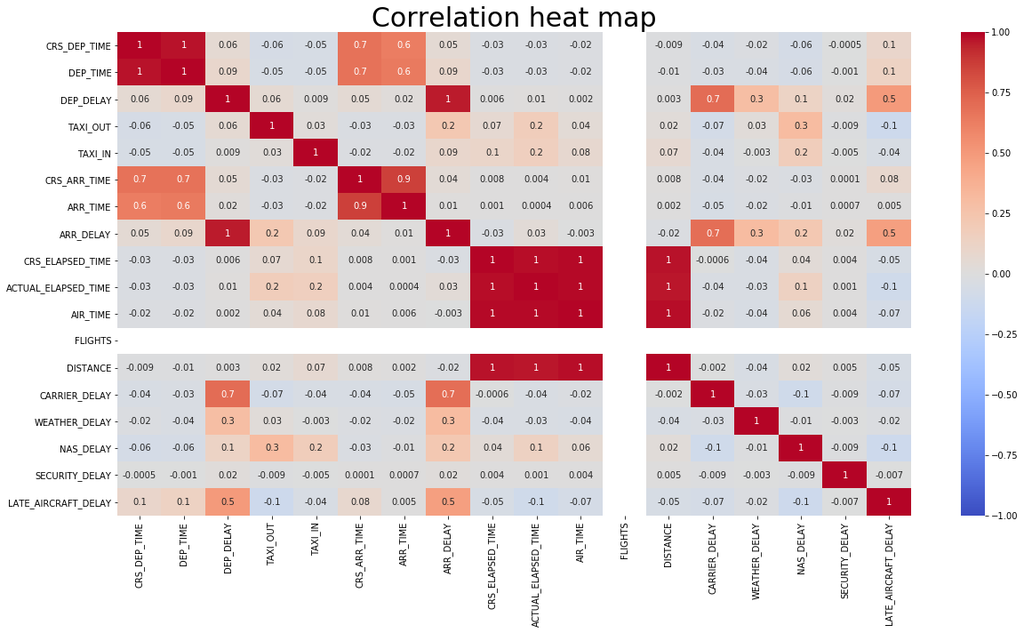

```python
#Plotting a heat map using correlation matrix
plt.figure(figsize=[20,10])
corrMatrix = all_data.corr()
sb.heatmap(corrMatrix, annot = True, vmin=-1, vmax=1, center= 0, cmap= 'coolwarm',fmt='.1g')
plt.title('Correlation heat map', size=30);
```

Out of the expected correlations, 70% correlation of CARRIER_DELAY with DEP_DELAY and ARR_DELAY can point out that most of the delays may be because of carriers.

## Multivariate Exploration

#### How does the number of flights to top 10 destinations change with time?

```python
#Calculate the number of flights performed
flights_real=all_data[all_data['CANCELLED']=='0.0']
```

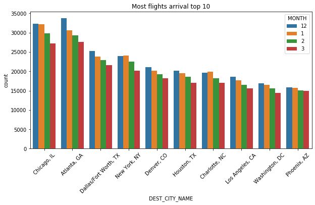

```python
plt.figure(figsize=[10,5])
sb.countplot(data=flights_real, x='DEST_CITY_NAME', order=flights_real.DEST_CITY_NAME.value_counts().iloc[:10].index, hue='MONTH', hue_order=["12", "1", "2", "3"] ).set_xticklabels(chart.get_xticklabels(), rotation=45)
plt.title('Most flights arrival top 10', size=12)
plt.figure(figsize=(15,50));
```

The order of the top 10 destination doesn't change with the top 10 planned destinations, however, we can see the decrease in the number of flights to these destinations with time clearly.

#### Are the arrival delays related with the destination and time? Let's use top 10 destination for this.

```python
#Create a dataframe to calculate mean of arrival delay time
dest_df=all_data.groupby(['DEST_CITY_NAME', 'MONTH'])['ARR_DELAY'].mean().reset_index()
dest_df.head(5)
```

|  | DEST_CITY_NAME | MONTH | ARR_DELAY |
| --- | --- | --- | --- |
| 0 | Aberdeen, SD | 1 | 3.550000 |
| 1 | Aberdeen, SD | 12 | 25.229508 |
| 2 | Aberdeen, SD | 2 | -18.517241 |
| 3 | Aberdeen, SD | 3 | -18.661017 |
| 4 | Abilene, TX | 1 | 9.370370 |

```python
dest_df.head(5)
```

|  | DEST_CITY_NAME | MONTH | ARR_DELAY |
| --- | --- | --- | --- |
| 0 | Aberdeen, SD | 1 | 3.550000 |
| 1 | Aberdeen, SD | 12 | 25.229508 |
| 2 | Aberdeen, SD | 2 | -18.517241 |
| 3 | Aberdeen, SD | 3 | -18.661017 |
| 4 | Abilene, TX | 1 | 9.370370 |

```python
top_10_city = ['Chicago, IL', 'Atlanta, GA', 'Dallas/Fort Worth, TX', 'New York, NY',
       'Denver, CO', 'Houston, TX', 'Charlotte, NC', 'Los Angeles, CA',
       'Washington, DC', 'Phoenix, AZ']
dest_df_top10 = dest_df[dest_df.DEST_CITY_NAME.isin(top_10_city)]
```

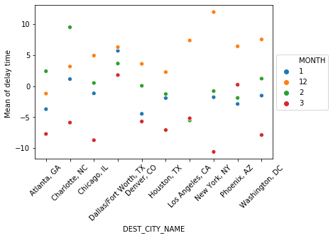

```python
sb.scatterplot(x=dest_df_top10.DEST_CITY_NAME, y=dest_df_top10.ARR_DELAY, hue=dest_df_top10.MONTH.astype('category')).legend(loc='center left', bbox_to_anchor=(1, 0.5))
plt.xticks(rotation=45)
plt.ylabel('Mean of delay time ');
```

According to plot above, there is no relation between the destination, delay time in arrival and time.

#### Are the majority of cancelled flights because of security reasons from the top 10 destinations?

```python
#Create a dataframe in which the flights are cancelled due to security reasons
security_canc=all_data[all_data['CANCELLATION_CODE']=='security']
sec_df_monthly=security_canc.groupby(['DEST_CITY_NAME', 'MONTH']).size().reset_index(name='counts')
sec_df_monthly=sec_df_monthly.sort_values(by=['counts'],ascending=False).head(10)
sec_df_monthly
```

|  | DEST_CITY_NAME | MONTH | counts |
| --- | --- | --- | --- |
| 56 | Chicago, IL | 3 | 6616 |
| 18 | Atlanta, GA | 3 | 6196 |
| 208 | New York, NY | 3 | 4139 |
| 71 | Dallas/Fort Worth, TX | 3 | 3894 |
| 163 | Las Vegas, NV | 3 | 3560 |
| 134 | Houston, TX | 3 | 3478 |
| 52 | Charlotte, NC | 3 | 3373 |
| 76 | Denver, CO | 3 | 3245 |
| 315 | Washington, DC | 3 | 2989 |
| 175 | Los Angeles, CA | 3 | 2402 |

[figure not shown]

```python
sb.barplot(data=sec_df_monthly, x='DEST_CITY_NAME', y='counts', hue='MONTH' ).set_xticklabels(chart.get_xticklabels(), rotation=45)
plt.title('Top 10 destinations of cancelled flights', size=12)
plt.figure(figsize=(15,50));
```